# 5. Introducción al deep learning (iii)

## Técnicas Avanzadas de Predicción en Negocios

### Juan D. Montoro-Pons | 2025/26

# Redes neuronales recurrentes

## Definición del problema: naturaleza secuencial de los datos

- Una red neuronal *feed forward* puede no ser adecuada con datos secuenciales (la hipótesis de independencia en las observaciones se rompe)
- Ejemplos:
  - Texto: orden de palabras es relevante.
  - Audio: transcripción o análisis musical.
  - Análisis de series temporales (finanzas, precios, producción) donde la predicción futura trata de explotar la autocorrelación existente en los datos.

## Redes Neuronales Recurrentes (RNN)

[figure not shown]

fdeloche (Own work, CC BY-SA 4.0) https://commons.wikimedia.org/w/index.php?curid=60109157

## Redes Neuronales Recurrentes (RNN)

Una RNN está diseñada para adecuarse y extraer patrones en datos que tienen naturaleza secuencial:

- Entrada: secuencia $X = {X_1, X_2, \dots, X_L}$ donde cada $X_\ell$ es un vector que utilizamos como entrada para alimentar la red.
- Secuencia de activaciones en una capa oculta: $H_\ell$ acumula contexto previo.
- Cada activación tiene como entrada el vector en $X_t$ y $H_{t-1}$
- Salida: la secuencia de activaciones $H_\ell$ alimentan la capa de salida y produce la secuencia $O_\ell$ (normalmente solo la última es de relevancia).
- Pesos compartidos: matrices $W$, $U$, $V$ se aplican en cada paso.

## RNN: ejemplo

Objetivo: predicción de una serie temporal univariante $X$ usando una ventana con las 4 observaciones anteriores ($x_5$ se predice con el vector $X_\ell=x_1\ldots x_4$). Suponemos una capa recurrente con 6 unidades ocultas.

- Las secuencias de 4 observaciones alimentan un conjunto de 6 unidades recurrentes, cada una de las cuales genera un estado oculto $h_t \in \mathbb{R}^6$ en cada instante $t$. La representación expandida de la dinámica temporal es:

  $$h_1 \to h_2 \to h_3 \to h_4 \to \text{Salida}$$
- En cada paso temporal $t$, el estado oculto se actualiza a partir de dos entradas: la observación en ese instante $x_t$ y el estado oculto anterior $h_{t-1}$. Por ejemplo, $h_3$ recibe $x_3$ y $h_2$.
- Los **pesos compartidos** de la capa recurrente comprenden:
  - $U$: pesos que transforman la entrada actual $x_t$,
  - $V$: pesos que transforman la memoria del paso anterior $h_{t-1}$,
  - $W$: pesos que conectan el estado oculto final con la capa de salida.

Estos pesos se reutilizan en todos los pasos temporales, lo que permite acumular información a lo largo de la secuencia.

## Actualización del estado oculto y salida

Para cada paso $\ell$:
$$H_\ell =g\left( U \, X_\ell+V \, H_{\ell-1}\right)$$
$$O_\ell = f(W\, H_\ell)$$

donde:

- $g(\cdot)$ = función de activación.
- $U$: pesos entrada-capa oculta.
- $V$: pesos capa oculta-capa oculta.
- $W$: pesos capa coulta-salida

## Entrenamiento

- Minimización de la función de pérdida (regresión)
  $$\text{L} = (Y - O_L)^2$$
- Actualización de pesos por retropropagación (incorporando la dependencia secuencial de los datos).
- Weight sharing: mismos pesos para toda la secuencia.
- Contexto acumulado: las activaciones $H_\ell$ resumen lo visto hasta $\ell$.
- Si bien las predicciones intermedias $O_\ell$ se descartan, en determinadas tareas (p.e. cuando la respuesta no es un escalar sino una secuencia) se puede hacer uso de ellas.

# Redes neuronales con memoria a largo plazo

## Redes LSTM

En general, una red neuronal recurrente tiene buena memoria a corto plazo pero mala a largo plazo. Debido a:

- Inestabilidad del gradiente: este es un problema común en la actualización de redes neuronales, donde la multiplicación sucesiva de la matriz de pesos recurrentes $V^{(k)}$ es inherentemente inestable y provoca que el gradiente desaparezca durante la retropropagación o que crezca desmesuradamente.
- Si el gradiente se desvanece los pesos en la entrada no se actualizan: dificultad para aprender a largo plazo cuando la secuencia de datos con la que alimentamos a la red neuronal es larga.

> Para abordar estos problemas, una solución consiste en cambiar la ecuación de recurrencia del vector oculto mediante el uso de LSTM, que incorpora memoria a largo plazo.

## LSTMs

Una red neuronal *Long short-term memory* incorpora tres modificaciones:

- Puertas (gates): son capas de redes neuronales que controlan el flujo de información.
- Estado de celda (cell state): un flujo de memoria independiente que puede mantener información a lo largo de muchos pasos temporales.
- Memoria selectiva (selective memory): La capacidad de elegir qué información es lo suficientemente importante como para recordarla a largo plazo.

## LSTMs

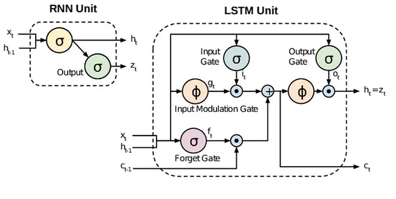

Fuente: Aggarwal (2023)

## LSTMs

Las neuronas de la capa oculta se sustituyen por una célula de memoria diseñada para capturar dependencias a largo plazo entre diferentes retardos de la serie temporal generando cuatro variables intermedias: puerta de entrada $i$, una puerta de olvido o puerta de retención $f$, estado de la célula $c$ y puerta de salida $o$.

1. Puerta de olvido: decide que información descartar del estádo de la célula. Toma como input la activación oculta anterior $h_{t-1}$ y el input actual $x_t$ y genera un número entre 0 y 1 que determina qué cantidad del estado previo $c_{t-1}$ se retiene.
2. Puerta de entrada. Actúa como filtro determinando qué parte de la nueva información debe almacenarse junto al estado de la célula $c_t$. Genera posibles valores (tanh) a añadir al estado y decide cuales añadir (sigmoid).
3. Actualización del estado de la célula: actualiza olvidando información (multiplicación por la puerta de olvido) y añadiendo nueva información (salida de la puerta de entrada).
4. Puerta de salida: determina que partes del estado de la célula deben influir el output actual. Combina el estado de la célula $c_t$ junto los valores de la puerta de salida.

## RNNs vs. LSTMs

|  | RNN | LSTM |
| --- | --- | --- |
| **Capacidad de memoria** | **Corto plazo** - Recuerdan con fiabilidad ~5–10 pasos de tiempo - Dificultad con dependencias a largo plazo - Ideales cuando importa sobre todo el contexto reciente | **Largo plazo:** - Pueden mantener información durante 100+ pasos de tiempo - Capturan dependencias de largo alcance - Adecuadas cuando se requiere contexto extenso |
| **Complejidad de entrenamiento** | **Más simples:** - Menos parámetros a entrenar - Menor propensión al sobreajuste en datasets pequeños | **Más complejas:** - $\approx$ 4× más parámetros que una RNN equivalente - Entrenamiento más lento por los cómputos de las puertas - Mejor generalización en tareas complejas |
| **Rendimiento según longitud de secuencia** | **Secuencias cortas (< 20 pasos):** suelen rendir tan bien como LSTM | **Secuencias medias (20–100):** empiezan a mostrar ventajas **Secuencias largas (100+):** superan claramente a las RNN |
| **Comparación en tareas: series temporales** | **Pronóstico a corto plazo:** eficaces para patrones y tendencias de corto plazo | **Estacionalidad y ciclos largos:** mejores capturando patrones estacionales y dependencias de largo plazo |